# Using the Census2016 Package to enrich election analysis

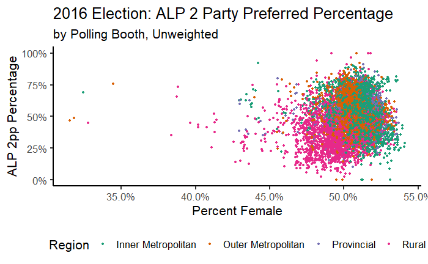

```r
polling_place_2pp_clean %>%
  ggplot(aes(y = ALP_Percent / 100, x = percent_female, colour = Demographic)) +
  geom_point(size = 1) +
  theme_classic(base_size = 16) + scale_color_brewer(palette = "Dark2") +
  theme(legend.position = "bottom") +
  scale_x_continuous(labels = scales::percent) +
  scale_y_continuous(labels = scales::percent) +
  labs(title = "2016 Election: ALP 2 Party Preferred Percentage",
       y = "ALP 2pp Percentage",
       x = "Percent Female", colour = "Region",
       subtitle = "by Polling Booth, Unweighted")
```

```r
polling_place_2pp_clean %>%
  dplyr::select(ALP_Percent, Swing, median_age, median_household_income,
                average_household_size, persons_per_bedroom, median_weekly_rent,
                median_annual_mortgage, percent_female, percent_defacto,
                percent_born_in_australia,
                percent_unit, percent_mortgage, percent_rent) %>%
  cor %>%
  kable()
```

|  | ALP_Percent | Swing | median_age | median_household_income | average_household_size | persons_per_bedroom | median_weekly_rent | median_annual_mortgage | percent_female | percent_defacto | percent_born_in_australia | percent_unit | percent_mortgage | percent_rent |
| --- | --- | --- | --- | --- | --- | --- | --- | --- | --- | --- | --- | --- | --- | --- |
| ALP_Percent | 1.0000000 | -0.2912343 | -0.4107650 | -0.0056240 | 0.1653612 | 0.3613836 | 0.1525497 | 0.1068924 | 0.1182998 | 0.1417798 | -0.3283471 | NA | NA | NA |
| Swing | -0.2912343 | 1.0000000 | 0.0514799 | 0.1105950 | -0.0781497 | 0.0236802 | 0.0899012 | 0.1048528 | 0.0807160 | -0.0001612 | -0.0461574 | NA | NA | NA |
| median_age | -0.4107650 | 0.0514799 | 1.0000000 | -0.4776289 | -0.5107579 | -0.5931916 | -0.4041044 | -0.4171832 | -0.0537144 | -0.0620614 | 0.5213940 | NA | NA | NA |
| median_household_income | -0.0056240 | 0.1105950 | -0.4776289 | 1.0000000 | 0.4138939 | 0.3353107 | 0.8079796 | 0.8679774 | 0.2015761 | -0.0669486 | -0.4025008 | NA | NA | NA |
| average_household_size | 0.1653612 | -0.0781497 | -0.5107579 | 0.4138939 | 1.0000000 | 0.3779623 | 0.3332586 | 0.3183454 | -0.0068105 | -0.5133083 | -0.2969940 | NA | NA | NA |
| persons_per_bedroom | 0.3613836 | 0.0236802 | -0.5931916 | 0.3353107 | 0.3779623 | 1.0000000 | 0.4035784 | 0.3926183 | -0.0036236 | 0.0290107 | -0.5889513 | NA | NA | NA |
| median_weekly_rent | 0.1525497 | 0.0899012 | -0.4041044 | 0.8079796 | 0.3332586 | 0.4035784 | 1.0000000 | 0.9280559 | 0.4262035 | -0.1258483 | -0.6024308 | NA | NA | NA |
| median_annual_mortgage | 0.1068924 | 0.1048528 | -0.4171832 | 0.8679774 | 0.3183454 | 0.3926183 | 0.9280559 | 1.0000000 | 0.3597541 | -0.1104388 | -0.5512846 | NA | NA | NA |
| percent_female | 0.1182998 | 0.0807160 | -0.0537144 | 0.2015761 | -0.0068105 | -0.0036236 | 0.4262035 | 0.3597541 | 1.0000000 | -0.0999105 | -0.1133221 | NA | NA | NA |
| percent_defacto | 0.1417798 | -0.0001612 | -0.0620614 | -0.0669486 | -0.5133083 | 0.0290107 | -0.1258483 | -0.1104388 | -0.0999105 | 1.0000000 | 0.2271308 | NA | NA | NA |
| percent_born_in_australia | -0.3283471 | -0.0461574 | 0.5213940 | -0.4025008 | -0.2969940 | -0.5889513 | -0.6024308 | -0.5512846 | -0.1133221 | 0.2271308 | 1.0000000 | NA | NA | NA |
| percent_unit | NA | NA | NA | NA | NA | NA | NA | NA | NA | NA | NA | 1 | NA | NA |
| percent_mortgage | NA | NA | NA | NA | NA | NA | NA | NA | NA | NA | NA | NA | 1 | NA |
| percent_rent | NA | NA | NA | NA | NA | NA | NA | NA | NA | NA | NA | NA | NA | 1 |

Note that there appear to be lots of NAs for the housing data. Need to fix/impute.

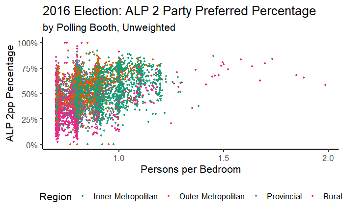

```r
polling_place_2pp_clean %>%
  ggplot(aes(y = ALP_Percent / 100, x = persons_per_bedroom,
             colour = Demographic)) +
  geom_point(size = 1) +
  theme_classic(base_size = 16) + scale_color_brewer(palette = "Dark2") +
  theme(legend.position = "bottom") +
  scale_y_continuous(labels = scales::percent) +
  labs(title = "2016 Election: ALP 2 Party Preferred Percentage",
       y = "ALP 2pp Percentage",
       x = "Persons per Bedroom", colour = "Region",
       subtitle = "by Polling Booth, Unweighted")
```

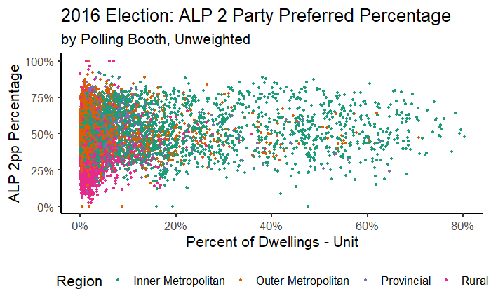

```r
polling_place_2pp_clean %>%
  ggplot(aes(y = ALP_Percent / 100, x = percent_unit, colour = Demographic)) +
  geom_point(size = 1) +
  theme_classic(base_size = 16) + scale_color_brewer(palette = "Dark2") +
  theme(legend.position = "bottom") +
  scale_y_continuous(labels = scales::percent) +
  scale_x_continuous(labels = scales::percent) +
  labs(title = "2016 Election: ALP 2 Party Preferred Percentage",
       y = "ALP 2pp Percentage",
       x = "Percent of Dwellings - Unit", colour = "Region",
       subtitle = "by Polling Booth, Unweighted")
```

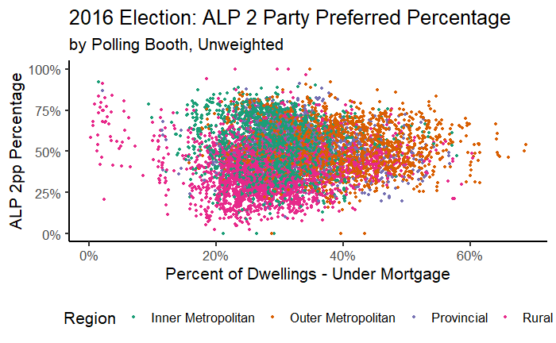

```r
polling_place_2pp_clean %>%
  ggplot(aes(y = ALP_Percent / 100, x = percent_mortgage,
             colour = Demographic)) +
  geom_point(size = 1) +
  theme_classic(base_size = 16) + scale_color_brewer(palette = "Dark2") +
  theme(legend.position = "bottom") +
  scale_y_continuous(labels = scales::percent) +
  scale_x_continuous(labels = scales::percent) +
  labs(title = "2016 Election: ALP 2 Party Preferred Percentage",
       y = "ALP 2pp Percentage",
       x = "Percent of Dwellings - Under Mortgage", colour = "Region",
       subtitle = "by Polling Booth, Unweighted")
```

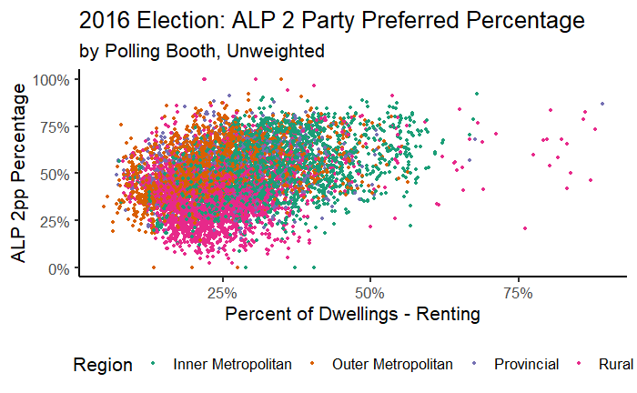

```r
polling_place_2pp_clean %>%
  ggplot(aes(y = ALP_Percent / 100, x = percent_rent, colour = Demographic)) +
  geom_point(size = 1) +
  theme_classic(base_size = 16) + scale_color_brewer(palette = "Dark2") +
  theme(legend.position = "bottom") +
  scale_y_continuous(labels = scales::percent) +
  scale_x_continuous(labels = scales::percent) +
  labs(title = "2016 Election: ALP 2 Party Preferred Percentage",
       y = "ALP 2pp Percentage",
       x = "Percent of Dwellings - Renting", colour = "Region",
       subtitle = "by Polling Booth, Unweighted")
```

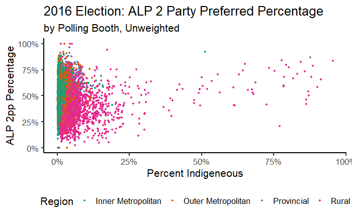

```r
polling_place_2pp_clean %>%
  ggplot(aes(y = ALP_Percent / 100, x = percent_indig, colour = Demographic)) +
  geom_point(size = 1) +
  theme_classic(base_size = 16) + scale_color_brewer(palette = "Dark2") +
  theme(legend.position = "bottom") +
  scale_y_continuous(labels = scales::percent) +
  scale_x_continuous(labels = scales::percent) +
  labs(title = "2016 Election: ALP 2 Party Preferred Percentage",
       y = "ALP 2pp Percentage",
       x = "Percent Indigeneous", colour = "Region",
       subtitle = "by Polling Booth, Unweighted")
```

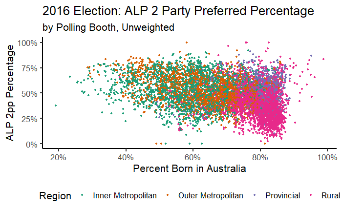

```r
polling_place_2pp_clean %>%
  ggplot(aes(y = ALP_Percent / 100, x = percent_born_in_australia,
             colour = Demographic)) +
  geom_point(size = 1) +
  theme_classic(base_size = 16) + scale_color_brewer(palette = "Dark2") +
  theme(legend.position = "bottom") +
  scale_y_continuous(labels = scales::percent) +
  scale_x_continuous(labels = scales::percent) +
  labs(title = "2016 Election: ALP 2 Party Preferred Percentage",
       y = "ALP 2pp Percentage",
       x = "Percent Born in Australia", colour = "Region",
       subtitle = "by Polling Booth, Unweighted")
```

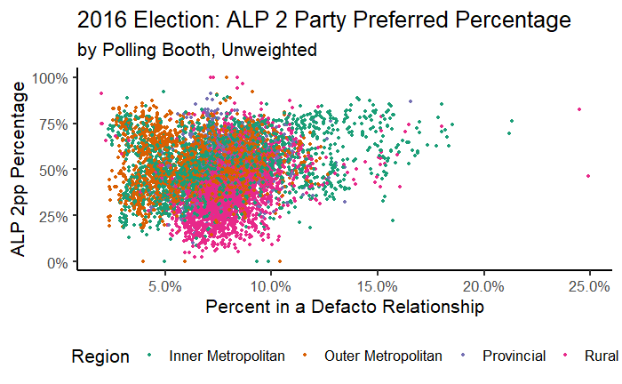

```r
polling_place_2pp_clean %>%
  ggplot(aes(y = ALP_Percent / 100, x = percent_defacto,
             colour = Demographic)) +
  geom_point(size = 1) +
  theme_classic(base_size = 16) + scale_color_brewer(palette = "Dark2") +
  theme(legend.position = "bottom") +
  scale_y_continuous(labels = scales::percent) +
  scale_x_continuous(labels = scales::percent) +
  labs(title = "2016 Election: ALP 2 Party Preferred Percentage",
       y = "ALP 2pp Percentage",
       x = "Percent in a Defacto Relationship", colour = "Region",
       subtitle = "by Polling Booth, Unweighted")
```

# 5 What to do next?

Add extra variables Look at lagged results Build models

# 6 Simple Model Building

## 6.1 Linear Models

Can we build a simple linear model to predict 2pp

```r
alp_2pp_lm_demog <-
  lm(ALP_Percent ~ median_household_income * Demographic + percent_indig +
       percent_female + percent_defacto + percent_born_in_australia +
       percent_rent + median_weekly_rent + median_age,
     data = polling_place_2pp_clean)

summary(alp_2pp_lm_demog)
```

[output not shown]

[output cut: 32 more lines]

[output not shown]

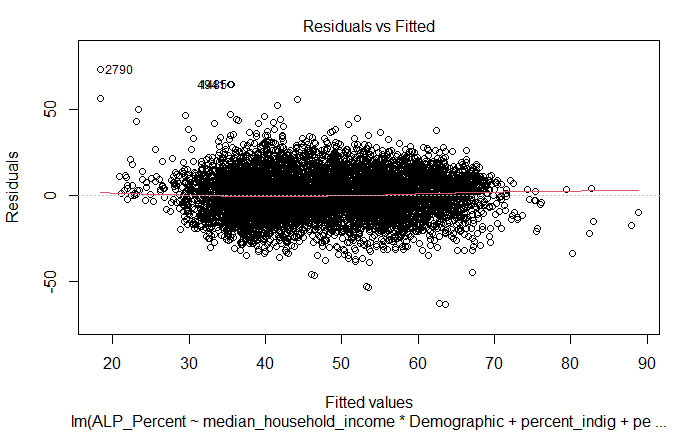

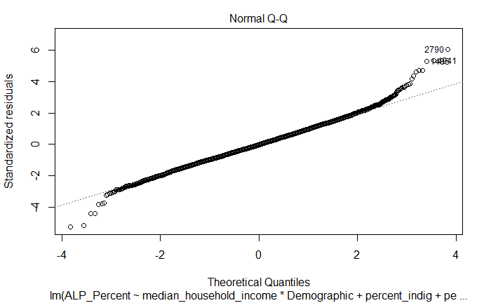

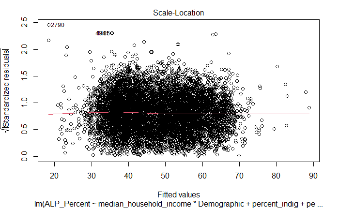

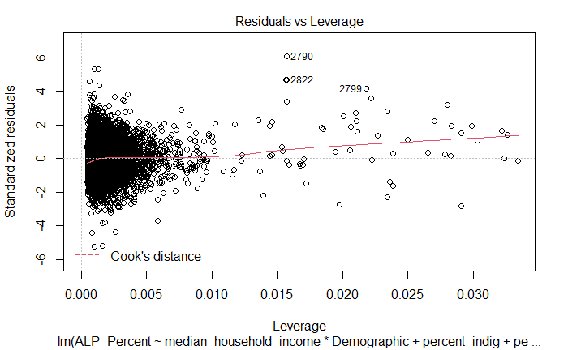

```r
plot(alp_2pp_lm_demog)
```

```r
vif(alp_2pp_lm_demog)
```

```
                                            GVIF Df GVIF^(1/(2*Df))
median_household_income                 7.316624  1        2.704926
Demographic                         18261.455172  3        5.131637
percent_indig                           1.706153  1        1.306198
percent_female                          1.650000  1        1.284523
percent_defacto                         1.614552  1        1.270650
percent_born_in_australia               4.563213  1        2.136168
percent_rent                            3.299426  1        1.816432
median_weekly_rent                      6.269462  1        2.503889
median_age                              3.407630  1        1.845977
median_household_income:Demographic 13002.761451  3        4.849228
```

```r
gv_alp_2pp_lm_demog <- gvlma(alp_2pp_lm_demog)
summary(gv_alp_2pp_lm_demog)
```

[output not shown]

[output cut: 17 more lines]

```
---
Signif. codes:  0 ‘***’ 0.001 ‘**’ 0.01 ‘*’ 0.05 ‘.’ 0.1 ‘ ’ 1

Residual standard error: 12.15 on 7775 degrees of freedom
  (52 observations deleted due to missingness)
Multiple R-squared:  0.3995,    Adjusted R-squared:  0.3984
F-statistic: 369.5 on 14 and 7775 DF,  p-value:< 0.00000000000000022


ASSESSMENT OF THE LINEAR MODEL ASSUMPTIONS
USING THE GLOBAL TEST ON 4 DEGREES-OF-FREEDOM:
Level of Significance =  0.05

Call:
 gvlma(x = alp_2pp_lm_demog)
```

|  | Value | p-value | Decision |
| --- | --- | --- | --- |
| Global Stat | 329.182557 | 0.0000000000000 | Assumptions NOT satisfied! |
| Skewness | 24.284965 | 0.0000008308505 | Assumptions NOT satisfied! |
| Kurtosis | 271.405688 | 0.0000000000000 | Assumptions NOT satisfied! |
| Link Function | 9.194152 | 0.0024278953937 | Assumptions NOT satisfied! |
| Heteroscedasticity | 24.297752 | 0.0000008253533 | Assumptions NOT satisfied! |

```r
alp_2pp_lm_demog <-
  lm(ALP_Percent ~ median_household_income + Demographic + percent_indig +
       percent_defacto + percent_born_in_australia +
       percent_rent + median_weekly_rent + median_age,
     data = polling_place_2pp_clean)

summary(alp_2pp_lm_demog)
```

[output not shown]

[output not shown]

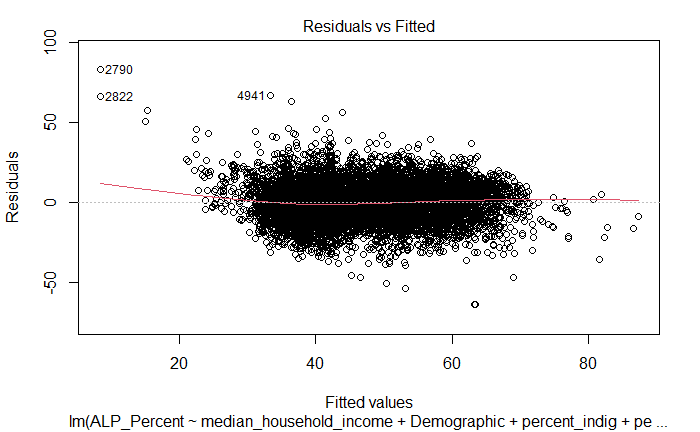

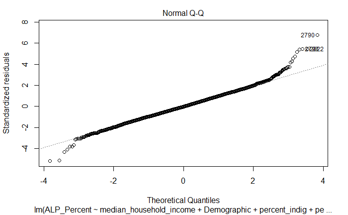

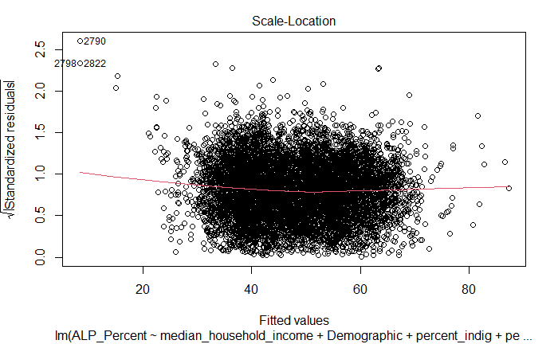

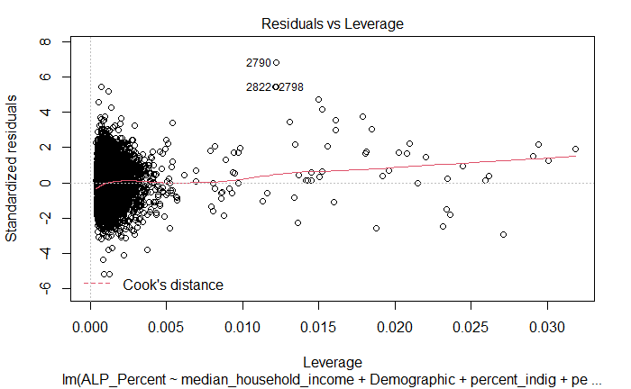

```r
anova(alp_2pp_lm_demog)
```

```r
vif(alp_2pp_lm_demog)
```

[output not shown]

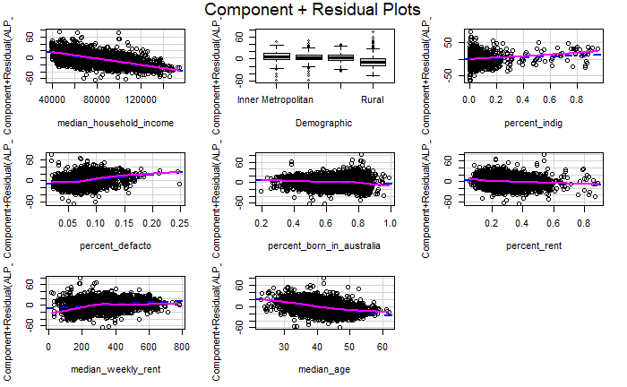

```r
crPlots(alp_2pp_lm_demog)
```

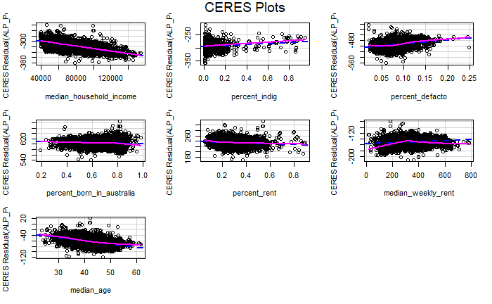

```r
ceresPlots(alp_2pp_lm_demog)
```

```r
gv_alp_2pp_lm_demog <- gvlma(alp_2pp_lm_demog)
summary(gv_alp_2pp_lm_demog)
```

[output not shown]

|  | Value | p-value | Decision |
| --- | --- | --- | --- |
| Global Stat | 514.92337 | 0.0000000000000000000000 | Assumptions NOT satisfied! |
| Skewness | 32.18477 | 0.0000000140185580921326 | Assumptions NOT satisfied! |
| Kurtosis | 377.91785 | 0.0000000000000000000000 | Assumptions NOT satisfied! |
| Link Function | 65.68330 | 0.0000000000000005551115 | Assumptions NOT satisfied! |
| Heteroscedasticity | 39.13745 | 0.0000000003949938154335 | Assumptions NOT satisfied! |

We know that income is important in the non-rural areas, so it might be worth adding an interaction between rural and non-rural and income.

What if we include the 2pp from the last election. It appears that Swing is defined as the swing to the Coalition between 2013 and 2016. So if we add the swing to the 2016 2pp, then we obtain the 2013 2pp.

When using a Linear Model, we can get an R^2 of about 84%

```r
polling_place_2pp_clean <- polling_place_2pp_clean %>%
  mutate(logit_ALP_Percent =
           log((ALP_Percent / 100) / (1 - ALP_Percent / 100)),
         logit_ALP_Percent_2013 =
           log((ALP_Percent_2013 / 100) / (1 - ALP_Percent_2013 / 100))) %>%
  filter(!is.nan(logit_ALP_Percent)) %>%
  filter(!is.na(logit_ALP_Percent)) %>%
  filter(!is.infinite(logit_ALP_Percent)) %>%
  filter(!is.nan(logit_ALP_Percent_2013)) %>%
  filter(!is.na(logit_ALP_Percent_2013)) %>%
  filter(!is.infinite(logit_ALP_Percent_2013))

alp_2pp_lm_demog_lag <-
  lm(logit_ALP_Percent ~ percent_indig + percent_defacto +
       percent_rent + median_weekly_rent + median_age +
       NonRural_Demographic * median_household_income + logit_ALP_Percent_2013,
     data = polling_place_2pp_clean)

summary(alp_2pp_lm_demog_lag)
```

```
Call:
lm(formula = logit_ALP_Percent ~ percent_indig + percent_defacto +
    percent_rent + median_weekly_rent + median_age + NonRural_Demographic *
    median_household_income + logit_ALP_Percent_2013, data = polling_place_2pp_clean)

Residuals:
    Min      1Q  Median      3Q     Max
-2.1110 -0.1297 -0.0042  0.1305  3.1633

Coefficients:
                                                  Estimate    Std. Error t value
(Intercept)                                   1.0959091994  0.0517826740  21.164
percent_indig                                 0.4115344175  0.0603756158   6.816
percent_defacto                               0.5801063962  0.1692442371   3.428
percent_rent                                 -0.3883763689  0.0480686113  -8.080
median_weekly_rent                            0.0002499617  0.0000599165   4.172
median_age                                   -0.0147752213  0.0009830689 -15.030
NonRural_Demographic                         -0.2116056651  0.0346441295  -6.108
median_household_income                      -0.0000051779  0.0000003219 -16.086
logit_ALP_Percent_2013                        0.8974069831  0.0060571128 148.158
NonRural_Demographic:median_household_income  0.0000020939  0.0000004902   4.272
                                                         Pr(>|t|)
(Intercept)                                  < 0.0000000000000002 ***
percent_indig                                0.000000000010048187 ***
percent_defacto                                          0.000612 ***
percent_rent                                 0.000000000000000748 ***
median_weekly_rent                           0.000030546066445595 ***
median_age                                   < 0.0000000000000002 ***
NonRural_Demographic                         0.000000001057798155 ***
median_household_income                      < 0.0000000000000002 ***
logit_ALP_Percent_2013                       < 0.0000000000000002 ***
NonRural_Demographic:median_household_income 0.000019646216040251 ***
---
Signif. codes:  0 ‘***’ 0.001 ‘**’ 0.01 ‘*’ 0.05 ‘.’ 0.1 ‘ ’ 1

Residual standard error: 0.2802 on 7733 degrees of freedom
  (52 observations deleted due to missingness)
Multiple R-squared:  0.8392,    Adjusted R-squared:  0.839
F-statistic:  4485 on 9 and 7733 DF,  p-value: < 0.00000000000000022
```

```r
anova(alp_2pp_lm_demog_lag)
```

```
Analysis of Variance Table

Response: logit_ALP_Percent
                                               Df  Sum Sq Mean Sq    F value
percent_indig                                   1    0.02    0.02     0.2255
percent_defacto                                 1   78.03   78.03   993.6088
percent_rent                                    1  415.03  415.03  5285.0079
median_weekly_rent                              1   28.44   28.44   362.1399
median_age                                      1  225.78  225.78  2875.1283
NonRural_Demographic                            1  290.25  290.25  3696.0787
median_household_income                         1  366.95  366.95  4672.7058
logit_ALP_Percent_2013                          1 1763.84 1763.84 22460.9325
NonRural_Demographic:median_household_income    1    1.43    1.43    18.2460
Residuals                                    7733  607.27    0.08
                                                            Pr(>F)
percent_indig                                               0.6349
percent_defacto                              < 0.00000000000000022 ***
percent_rent                                 < 0.00000000000000022 ***
median_weekly_rent                           < 0.00000000000000022 ***
median_age                                   < 0.00000000000000022 ***
NonRural_Demographic                         < 0.00000000000000022 ***
median_household_income                      < 0.00000000000000022 ***
logit_ALP_Percent_2013                       < 0.00000000000000022 ***
NonRural_Demographic:median_household_income            0.00001965 ***
Residuals
---
Signif. codes:  0 ‘***’ 0.001 ‘**’ 0.01 ‘*’ 0.05 ‘.’ 0.1 ‘ ’ 1
```

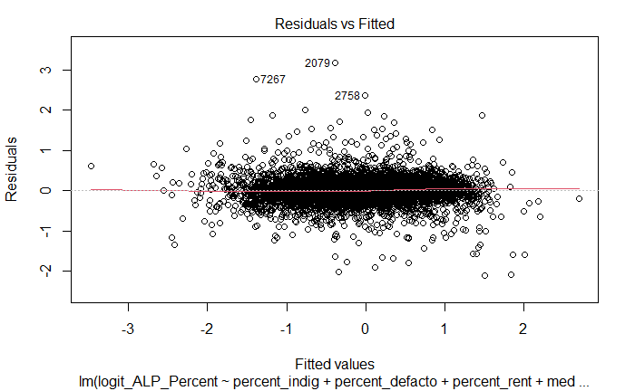

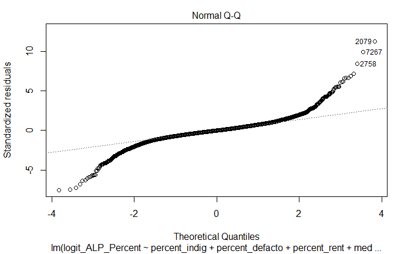

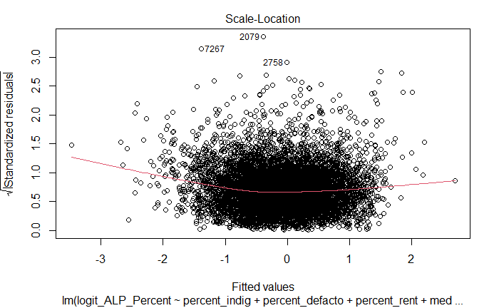

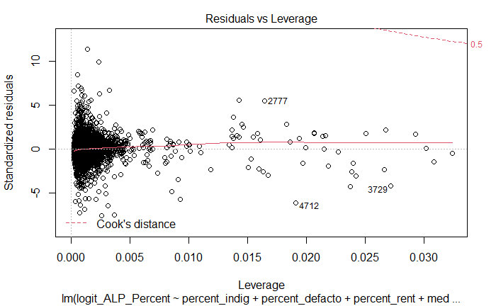

```r
plot(alp_2pp_lm_demog_lag)
```

```r
vif(alp_2pp_lm_demog_lag)
```

```
                               percent_indig
                                    1.502748
                             percent_defacto
                                    1.366026
                                percent_rent
                                    2.262058
                          median_weekly_rent
                                    4.328613
                                  median_age
                                    2.884030
                        NonRural_Demographic
                                   27.998884
                     median_household_income
                                    4.532365
                      logit_ALP_Percent_2013
                                    1.598839
NonRural_Demographic:median_household_income
                                   21.897932
```

```r
gv_alp_2pp_lm_demog_lag <- gvlma(alp_2pp_lm_demog_lag)
summary(alp_2pp_lm_demog_lag)
```

```
Call:
lm(formula = logit_ALP_Percent ~ percent_indig + percent_defacto +
    percent_rent + median_weekly_rent + median_age + NonRural_Demographic *
    median_household_income + logit_ALP_Percent_2013, data = polling_place_2pp_clean)

Residuals:
    Min      1Q  Median      3Q     Max
-2.1110 -0.1297 -0.0042  0.1305  3.1633

Coefficients:
                                                  Estimate    Std. Error t value
(Intercept)                                   1.0959091994  0.0517826740  21.164
percent_indig                                 0.4115344175  0.0603756158   6.816
percent_defacto                               0.5801063962  0.1692442371   3.428
percent_rent                                 -0.3883763689  0.0480686113  -8.080
median_weekly_rent                            0.0002499617  0.0000599165   4.172
median_age                                   -0.0147752213  0.0009830689 -15.030
NonRural_Demographic                         -0.2116056651  0.0346441295  -6.108
median_household_income                      -0.0000051779  0.0000003219 -16.086
logit_ALP_Percent_2013                        0.8974069831  0.0060571128 148.158
NonRural_Demographic:median_household_income  0.0000020939  0.0000004902   4.272
                                                         Pr(>|t|)
(Intercept)                                  < 0.0000000000000002 ***
percent_indig                                0.000000000010048187 ***
percent_defacto                                          0.000612 ***
percent_rent                                 0.000000000000000748 ***
median_weekly_rent                           0.000030546066445595 ***
median_age                                   < 0.0000000000000002 ***
NonRural_Demographic                         0.000000001057798155 ***
median_household_income                      < 0.0000000000000002 ***
logit_ALP_Percent_2013                       < 0.0000000000000002 ***
NonRural_Demographic:median_household_income 0.000019646216040251 ***
---
Signif. codes:  0 ‘***’ 0.001 ‘**’ 0.01 ‘*’ 0.05 ‘.’ 0.1 ‘ ’ 1

Residual standard error: 0.2802 on 7733 degrees of freedom
  (52 observations deleted due to missingness)
Multiple R-squared:  0.8392,    Adjusted R-squared:  0.839
F-statistic:  4485 on 9 and 7733 DF,  p-value: < 0.00000000000000022
```

It would be interesting to see whether 2013 alone is a good predictor. Fitting this model gives an R^2 of 82.7%. This means that the other variables add a bit, but not a huge amount.

```r
alp_2pp_lm_demog_lag <-
  lm(logit_ALP_Percent ~ logit_ALP_Percent_2013,
     data = polling_place_2pp_clean)

summary(alp_2pp_lm_demog_lag)
```

```
Call:
lm(formula = logit_ALP_Percent ~ logit_ALP_Percent_2013, data = polling_place_2pp_clean)

Residuals:
    Min      1Q  Median      3Q     Max
-2.2357 -0.1441 -0.0115  0.1335  3.2092

Coefficients:
                       Estimate Std. Error t value            Pr(>|t|)
(Intercept)            0.127440   0.003472    36.7 <0.0000000000000002 ***
logit_ALP_Percent_2013 0.954281   0.004944   193.0 <0.0000000000000002 ***
---
Signif. codes:  0 ‘***’ 0.001 ‘**’ 0.01 ‘*’ 0.05 ‘.’ 0.1 ‘ ’ 1

Residual standard error: 0.2902 on 7793 degrees of freedom
Multiple R-squared:  0.827, Adjusted R-squared:  0.827
F-statistic: 3.725e+04 on 1 and 7793 DF,  p-value: < 0.00000000000000022
```

```r
anova(alp_2pp_lm_demog_lag)
```

```
Analysis of Variance Table

Response: logit_ALP_Percent
                         Df  Sum Sq Mean Sq F value                Pr(>F)
logit_ALP_Percent_2013    1 3136.83 3136.83   37249 < 0.00000000000000022 ***
Residuals              7793  656.27    0.08
---
Signif. codes:  0 ‘***’ 0.001 ‘**’ 0.01 ‘*’ 0.05 ‘.’ 0.1 ‘ ’ 1
```

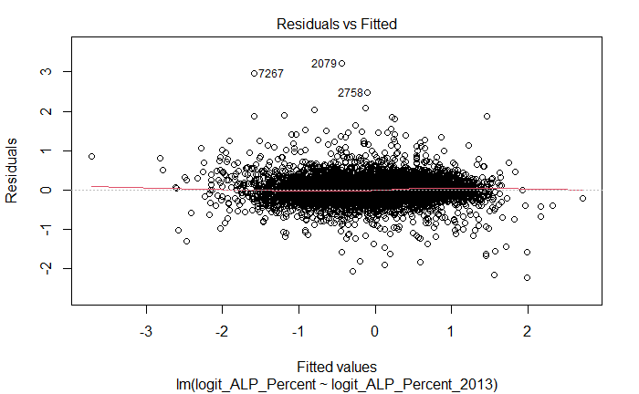

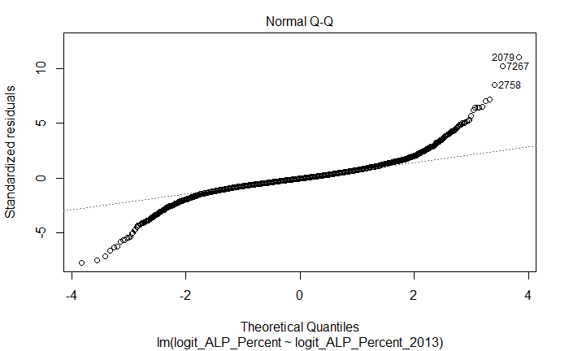

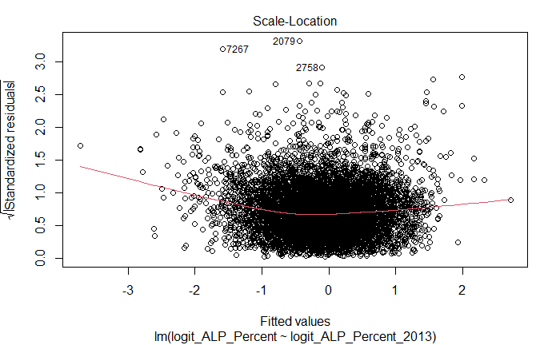

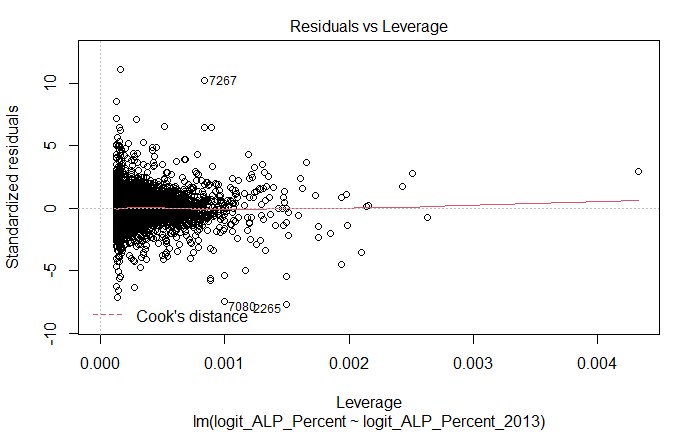

```r
plot(alp_2pp_lm_demog_lag)
```

There are three outlying values - let"s explore these

```r
polling_place_2pp_clean[c(2079, 7267, 2758), ]
```

| year | StateAb | DivisionNm | PollingPlaceID | PollingPlace | median_age | median_household_income | average_household_size | persons_per_bedroom | median_weekly_rent | median_annual_mortgage | percent_female | percent_defacto | percent_married | percent_indig | percent_born_in_australia | percent_unit | percent_mortgage | percent_rent | LNP_Votes | LNP_Percent | ALP_Votes | ALP_Percent | TotalVotes | Swing | Latitude | Longitude | DivisionID | PremisesPostCode | Division | … |
| --- | --- | --- | --- | --- | --- | --- | --- | --- | --- | --- | --- | --- | --- | --- | --- | --- | --- | --- | --- | --- | --- | --- | --- | --- | --- | --- | --- | --- | --- | --- |
| 2016 | NSW | PARKES | 82529 | REMOTE MOBILE TEAM 3 | 37.11765 | 65951.29 | 2.576471 | 0.8000000 | 111.1765 | 12158.82 | 0.4818636 | 0.08387193 | 0.2927193 | 0.17218070 | 0.8216821 | 0.016731235 | 0.1842660 | 0.3605756 | 1 | 5.88 | 16 | 94.12 | 17 | -58.47 | NA | NA | 139 | 2409 | Parkes | … |
| 2016 | WA | COWAN | 65417 | BLV COWAN PPVC | 35.81818 | 78520.00 | 2.800000 | 0.7818182 | 363.6364 | 22341.82 | 0.5033956 | 0.07186575 | 0.3497584 | 0.02160607 | 0.5679440 | 0.003953797 | 0.4568424 | 0.2004679 | 2 | 20.00 | 8 | 80.00 | 10 | -65.71 | -31.80767 | 115.7900 | 237 | 6027 | Cowan | … |
| 2016 | NSW | WHITLAM | 33615 | SPECIAL HOSPITAL TEAM 1 | 40.06897 | 65407.03 | 2.658621 | 0.8000000 | 333.4483 | 21095.59 | 0.5132591 | 0.07150519 | 0.3501742 | 0.04250609 | 0.7693975 | 0.041689373 | 0.3309418 | 0.2608076 | 3 | 8.57 | 32 | 91.43 | 35 | -47.35 | -33.95670 | 151.0683 | 150 | NA | Whitlam | … |

These booths have fewer than 40 electors, and fewer than 5 for one of the two parties. They are also “non-standard” booths.

It might be interesting to see which booths deviate from the division mean.

## 6.3 Trying GBM

Can we fit a gradient boosting machine to improve fit (while trading off raw explainability)

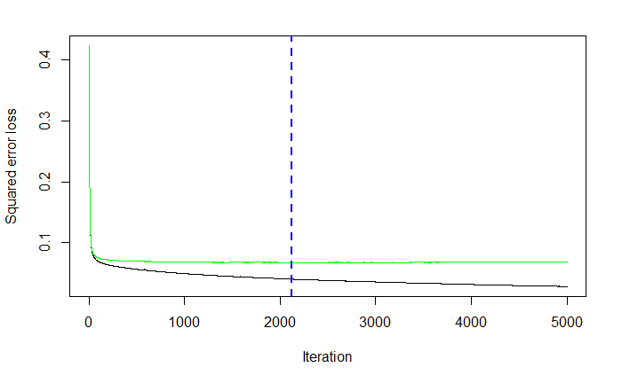

```r
polling_place_2pp_gbm <- polling_place_2pp_clean %>%
  clean_names() %>%
  dplyr::select(-year, -division_nm, -polling_place_id, -polling_place,
                -division, -premises_post_code, -division_id, -state,
                -enrolment, -successful_party, -seat_status, -alp_percent,
                -lnp_percent, -lnp_votes, -alp_votes, -total_votes, -swing) %>%
  mutate(state_ab = factor(state_ab),
         demographic = factor(demographic),
         previous_party = factor(previous_party),
         previous_seat_status = factor(previous_seat_status))


polling_place_2pp_split <- initial_split(polling_place_2pp_gbm, prop = .8)
polling_place_2pp_train <- training(polling_place_2pp_split)
polling_place_2pp_test  <- testing(polling_place_2pp_split)


polling_place_2pp_gbm1 <- gbm::gbm(logit_alp_percent ~.,
                                   data = polling_place_2pp_train,
                                   distribution = "gaussian",
                                   verbose = F,
                                   shrinkage = 0.1,
                                   interaction.depth = 2,
                                   n.minobsinnode = 10,
                                   n.trees = 5000,
                                   cv.folds = 10)

perf_gbm1 <- gbm.perf(polling_place_2pp_gbm1, method = "cv")
```

```r
polling_place_2pp_prediction_1 <- stats::predict(
  object = polling_place_2pp_gbm1,
  newdata = polling_place_2pp_test,
  n.trees = perf_gbm1)
rmse_fit1 <- Metrics::rmse(actual = polling_place_2pp_test$logit_alp_percent,
                           predicted = polling_place_2pp_prediction_1)
print(rmse_fit1)
```

```
[1] 0.2518863
```

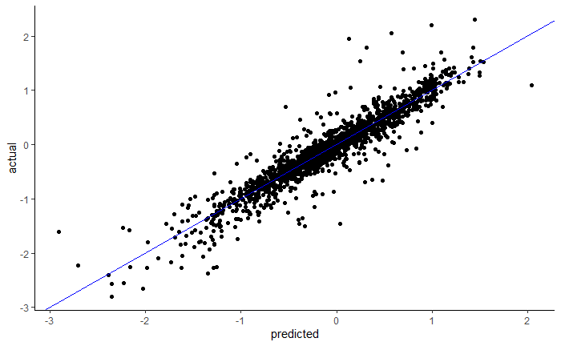

```r
data.frame(actual = polling_place_2pp_test$logit_alp_percent,
           predicted = polling_place_2pp_prediction_1) %>%
  ggplot(aes(x = predicted, y = actual)) + geom_point() +
  geom_abline(slope = 1, intercept = 0, colour = "blue") +
  theme_classic()
```

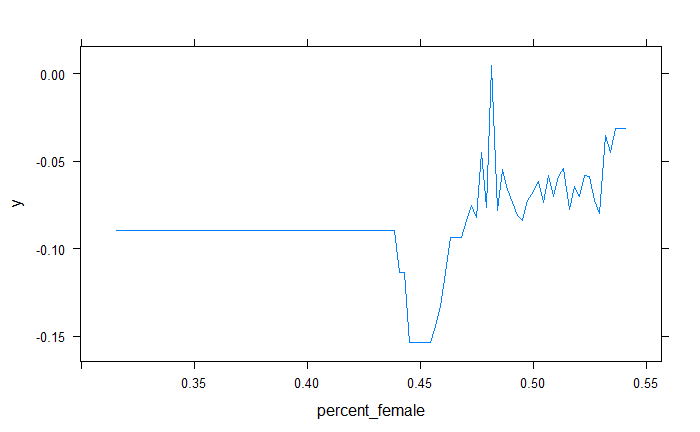

```r
gbm::plot.gbm(polling_place_2pp_gbm1, i.var = 8)
```

When looking at variable importance, it is clear that the most important factor is the 2pp vote in the previous election.

```r
polling_place_2pp_effects <-
  tibble::as_tibble(gbm::summary.gbm(polling_place_2pp_gbm1, plotit = FALSE))
polling_place_2pp_effects %>% utils::head(n = 15)
```

| var | rel.inf |
| --- | --- |
| alp_percent_2013 | 58.2538467 |
| latitude | 11.4905829 |
| longitude | 11.3392437 |
| percent_indig | 1.7371309 |
| median_annual_mortgage | 1.5700879 |
| median_weekly_rent | 1.5406146 |
| persons_per_bedroom | 1.4757418 |
| previous_party | 1.3272479 |
| percent_defacto | 1.2550578 |
| average_household_size | 1.0808726 |

[output cut: 5 more lines]

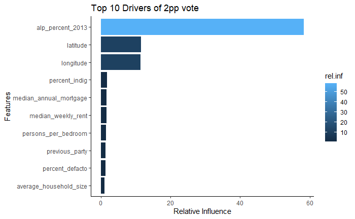

```r
polling_place_2pp_effects %>%
  # arrange descending to get the top influencers
  dplyr::arrange(desc(rel.inf)) %>%
  # sort to top 10
  dplyr::top_n(10) %>%
  # plot these data using columns
  ggplot(aes(x = forcats::fct_reorder(.f = var,
                                      .x = rel.inf),
             y = rel.inf,
             fill = rel.inf)) +
  geom_col() +
  # flip
  coord_flip() +
  # format
  scale_color_brewer(palette = "Dark2") +
  theme(axis.title = element_text()) +
  theme_classic() +
  xlab("Features") +
  ylab("Relative Influence") +
  ggtitle("Top 10 Drivers of 2pp vote")
```

### 6.3.1 Using the Stacks package to compare models

We can use the skim function to summarise the covariates and outcome variables that we will be modelling on.

```r
polling_place_2pp_model <- polling_place_2pp_clean %>%
  clean_names() %>%
  dplyr::select(-year, -division_nm, -polling_place_id, -polling_place,
                -division, -premises_post_code, -division_id, -state,
                -enrolment, -successful_party, -seat_status, -alp_percent,
                -lnp_percent, -lnp_votes, -alp_votes, -total_votes, -swing,
                -alp_percent_2013) %>%
  mutate(state_ab = factor(state_ab),
         demographic = factor(demographic),
         previous_party = factor(previous_party),
         previous_seat_status = factor(previous_seat_status))

skim(polling_place_2pp_model)
```

```
-- Data Summary ------------------------
                           Values
Name                       polling_place_2pp_model
Number of rows             7795
Number of columns          23
_______________________
Column type frequency:
  factor                   4
  numeric                  19
________________________
Group variables            None

-- Variable type: factor --------------------------------------------------------
# A tibble: 4 x 6
  skim_variable        n_missing complete_rate ordered n_unique
* <chr>                    <int>         <dbl> <lgl>      <int>
1 state_ab                     0             1 FALSE          8
2 demographic                  0             1 FALSE          4
3 previous_party               0             1 FALSE          9
4 previous_seat_status         0             1 FALSE          3
  top_counts
* <chr>
1 NSW: 2670, VIC: 1740, QLD: 1535, SA: 693
2 Rur: 2975, Inn: 1944, Out: 1767, Pro: 1109
3 Lib: 3092, Aus: 2394, Lib: 1120, The: 839
4 Saf: 3276, Mar: 3086, Fai: 1433

-- Variable type: numeric -------------------------------------------------------
# A tibble: 19 x 11
   skim_variable             n_missing complete_rate       mean         sd
 * <chr>                         <int>         <dbl>      <dbl>      <dbl>
 1 median_age                        0         1        40.3        5.50
 2 median_household_income           0         1     74775.     21124.
 3 average_household_size            0         1         2.57       0.304
 4 persons_per_bedroom               0         1         0.833      0.105
 5 median_weekly_rent                0         1       318.       110.
 6 median_annual_mortgage            0         1     20827.      5666.
 7 percent_female                    0         1         0.504      0.0156
 8 percent_defacto                   0         1         0.0761     0.0220
 9 percent_married                   0         1         0.346      0.0509
```

[output cut: 16 more lines]

```
 5    16.2        242.        321.       383.        786.    ▂▇▇▁▁
 6   266.       16522.      20809.     24219.      41242.    ▁▃▇▃▁
 7     0.315        0.497       0.507      0.514       0.541 ▁▁▁▂▇
 8     0.0202       0.0646      0.0764     0.0864      0.249 ▃▇▁▁▁
 9     0.0598       0.319       0.351      0.379       0.507 ▁▁▃▇▁
10     0.000863     0.00802     0.0190     0.0404      0.954 ▇▁▁▁▁
11     0.192        0.620       0.743      0.808       0.987 ▁▂▃▇▂
12     0            0.0112      0.0309     0.0951      0.802 ▇▁▁▁▁
13     0.00238      0.262       0.307      0.368       0.687 ▁▅▇▂▁
14     0.0498       0.200       0.257      0.322       0.891 ▅▇▂▁▁
15   -43.4        -36.5       -33.9      -30.5        57.9   ▇▁▁▁▁
16   -95.7        145.        148.       151.        168.    ▁▁▁▁▇
17     0            0           0          1           1     ▇▁▁▁▅
18    -3.77        -0.524      -0.102      0.369       3.33  ▁▁▇▂▁
19    -4.03        -0.636      -0.218      0.205       2.71  ▁▁▇▅▁
```

We can see that there is some missing data for latitude, longitude, and dwelling statistics. We will impute these using KNN imputation.

```r
polling_place_2pp_split <- initial_split(polling_place_2pp_model, prop = .8)
polling_place_2pp_train <- training(polling_place_2pp_split)
polling_place_2pp_test  <- testing(polling_place_2pp_split)


training_folds <- vfold_cv(polling_place_2pp_train, v = 10)

polling_place_2pp_rec <- recipe(logit_alp_percent ~ .,
                                data = polling_place_2pp_train) %>%
  step_knnimpute(all_predictors()) %>%
  step_dummy(all_predictors(), -all_numeric())

metric <- metric_set(rmse)
```

Create some candidate models

```r
ctrl_grid <- control_stack_grid()
ctrl_res <- control_stack_resamples()
```

#### 6.3.1.1 Linear Regression

```r
lm_spec <-
  linear_reg() %>%
  set_engine("lm")

lm_wflow <-
  workflow() %>%
  add_model(lm_spec) %>%
  add_recipe(polling_place_2pp_rec)

lm_resample <-
  fit_resamples(
    lm_wflow,
    resamples = training_folds,
    metrics = metric,
    control = ctrl_res
  )
```

[output not shown]

#### 6.3.1.2 Linear regression with lasso

```r
lasso_spec <-
  linear_reg(penalty = tune("pen"), mixture = tune("mix")) %>%
  set_engine("glmnet")

lasso_wflow <-
  workflow() %>%
  add_model(lasso_spec) %>%
  add_recipe(polling_place_2pp_rec)

#Fix
lasso_resample <-
  tune_grid(
    lasso_wflow,
    resamples = training_folds,
    metrics = metric,
    grid = 6,
    control = ctrl_res
  )
```

```
The workflow being saved contains a recipe, which is 1.04 Mb in memory. If this was not intentional, please set the control setting `save_workflow = FALSE`.
```

#### 6.3.1.3 Random Forest

```r
random_forest_spec <-
  rand_forest(mode = "regression", mtry = tune("num_pred"),
              min_n = tune("min_n")) %>%
  set_engine("ranger")

random_forest_wflow <-
  workflow() %>%
  add_model(random_forest_spec) %>%
  add_recipe(polling_place_2pp_rec)

#Fix
random_forest_resample <-
  tune_grid(
    random_forest_wflow,
    resamples = training_folds,
    metrics = metric,
    grid = 6,
    control = ctrl_res
  )
```

```
i Creating pre-processing data to finalize unknown parameter: num_pred
The workflow being saved contains a recipe, which is 1.04 Mb in memory. If this was not intentional, please set the control setting `save_workflow = FALSE`.
```

#### 6.3.1.4 K nearest neighbours

```r
knn_spec <-
  nearest_neighbor(
    mode = "regression",
    neighbors = tune("k")
  ) %>%
  set_engine("kknn")

knn_wflow <-
  workflow() %>%
  add_model(knn_spec) %>%
  add_recipe(polling_place_2pp_rec)

#Fix
knn_resample <-
  tune_grid(
    knn_wflow,
    resamples = training_folds,
    metrics = metric,
    grid = 6,
    control = ctrl_res
  )
```

```
The workflow being saved contains a recipe, which is 1.04 Mb in memory. If this was not intentional, please set the control setting `save_workflow = FALSE`.
```

#### 6.3.1.5 Gradient boosting machine

```r
gbm_spec <-
  boost_tree(
    min_n = tune("min_n"),
    tree_depth = tune("tree_depth"),
    learn_rate = tune("learn_rate"),
    loss_reduction = tune("loss_reduction")
  ) %>%
  set_engine("xgboost") %>%
  set_mode("regression")

gbm_wflow <-
  workflow() %>%
  add_model(gbm_spec) %>%
  add_recipe(polling_place_2pp_rec)

#Fix
gbm_resample <-
  tune_grid(
    gbm_wflow,
    resamples = training_folds,
    metrics = metric,
    grid = 80,
    control = ctrl_res
  )
```

```
The workflow being saved contains a recipe, which is 1.04 Mb in memory. If this was not intentional, please set the control setting `save_workflow = FALSE`.
```

#### 6.3.1.6 Support Vector Machine

```r
svm_spec <-
  svm_rbf(
    cost = tune("cost"),
    rbf_sigma = tune("sigma")
  ) %>%
  set_engine("kernlab") %>%
  set_mode("regression")


svm_wflow <-
  workflow() %>%
  add_model(svm_spec) %>%
  add_recipe(polling_place_2pp_rec)

#Fix
svm_resample <-
  tune_grid(
    svm_wflow,
    resamples = training_folds,
    metrics = metric,
    grid = 6,
    control = ctrl_res
  )
```

```
The workflow being saved contains a recipe, which is 1.04 Mb in memory. If this was not intentional, please set the control setting `save_workflow = FALSE`.
```

#### 6.3.1.7 Creating a ensemble of these models

```r
polling_place_2pp_stack <-
  stacks() %>%
  add_candidates(lm_resample) %>%
  add_candidates(lasso_resample) %>%
  add_candidates(random_forest_resample) %>%
  add_candidates(knn_resample) %>%
  add_candidates(gbm_resample) %>%
  add_candidates(svm_resample)
```

[output not shown]

```r
polling_place_2pp_stack <-
  polling_place_2pp_stack %>%
  blend_predictions()
```

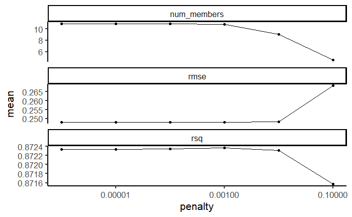

```r
theme_set(theme_classic(base_size = 16))
autoplot(polling_place_2pp_stack)
```

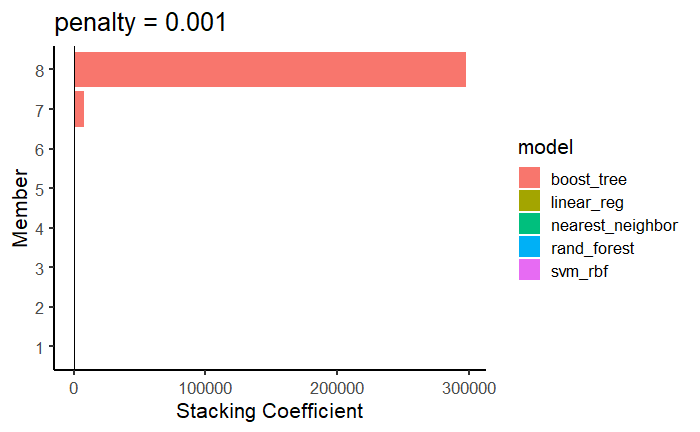

```r
autoplot(polling_place_2pp_stack, type = "weights")
```

```r
polling_place_2pp_stack <-
  polling_place_2pp_stack %>%
  fit_members()
```

```r
collect_parameters(polling_place_2pp_stack, "lasso_resample")
```

| member | pen | mix | coef |
| --- | --- | --- | --- |
| lasso_resample_1_1 | 0.0000067030661554 | 0.08134805 | 0 |
| lasso_resample_1_2 | 0.0000000084266202 | 0.24686784 | 0 |
| lasso_resample_1_3 | 0.0000300351424908 | 0.41683582 | 0 |
| lasso_resample_1_4 | 0.0153050935194247 | 0.53277308 | 0 |
| lasso_resample_1_5 | 0.0000000001096363 | 0.81669752 | 0 |
| lasso_resample_1_6 | 0.5504291261129236 | 0.96622525 | 0 |

```r
collect_parameters(polling_place_2pp_stack, "knn_resample")
```

| member | k | coef |
| --- | --- | --- |
| knn_resample_1_1 | 2 | 0.00000000 |
| knn_resample_1_2 | 4 | 0.04466860 |
| knn_resample_1_3 | 8 | 0.09301966 |
| knn_resample_1_4 | 9 | 0.00000000 |
| knn_resample_1_5 | 13 | 0.00000000 |
| knn_resample_1_6 | 14 | 0.00000000 |

```r
collect_parameters(polling_place_2pp_stack, "random_forest_resample")
```

| member | num_pred | min_n | coef |
| --- | --- | --- | --- |
| random_forest_resample_1_1 | 9 | 12 | 0.1422700 |
| random_forest_resample_1_2 | 1 | 20 | 0.0000000 |
| random_forest_resample_1_3 | 26 | 37 | 0.0000000 |
| random_forest_resample_1_4 | 18 | 8 | 0.4937276 |
| random_forest_resample_1_5 | 33 | 32 | 0.0000000 |
| random_forest_resample_1_6 | 23 | 24 | 0.0000000 |

```r
collect_parameters(polling_place_2pp_stack, "gbm_resample")
```

| member | min_n | tree_depth | learn_rate | loss_reduction | coef |
| --- | --- | --- | --- | --- | --- |
| gbm_resample_1_01 | 24 | 13 | 0.0000000105530322 | 0.0004085194252548 | 0.000 |
| gbm_resample_1_02 | 17 | 7 | 0.0022473734873020 | 1.2928751587354523 | 0.000 |
| gbm_resample_1_03 | 32 | 4 | 0.0000000065656022 | 0.0000003326065632 | 298075.838 |
| gbm_resample_1_04 | 20 | 14 | 0.0000000004907635 | 0.0000071323838456 | NA |
| gbm_resample_1_05 | 21 | 8 | 0.0000824635526433 | 6.8672475586374233 | 0.000 |
| gbm_resample_1_06 | 40 | 14 | 0.0000014914933261 | 0.0615789791642289 | 0.000 |
| gbm_resample_1_07 | 25 | 9 | 0.0001789675388186 | 27.2396654753554692 | 0.000 |
| gbm_resample_1_08 | 2 | 10 | 0.0297557352977784 | 0.0000000320765454 | 0.000 |
| gbm_resample_1_09 | 35 | 6 | 0.0000000470422067 | 0.0005860480461150 | 0.000 |
| gbm_resample_1_10 | 39 | 2 | 0.0000039592287232 | 20.7875770552130028 | 0.000 |

[output cut: 70 more lines]

```r
collect_parameters(polling_place_2pp_stack, "svm_resample")
```

| member | cost | sigma | coef |
| --- | --- | --- | --- |
| svm_resample_1_1 | 15.45534315 | 0.000000009024860 | 0.00000000 |
| svm_resample_1_2 | 0.45867785 | 0.000502903314948 | 0.00000000 |
| svm_resample_1_3 | 2.71953400 | 0.881217704531199 | 0.01432119 |
| svm_resample_1_4 | 0.01436298 | 0.000238946398994 | 0.00000000 |
| svm_resample_1_5 | 0.08317744 | 0.000000003680224 | 0.00000000 |
| svm_resample_1_6 | 0.00141805 | 0.000001153196500 | 0.00000000 |

#### 6.3.1.8 Testing

```r
polling_place_2pp_test <-
  polling_place_2pp_test %>%
  bind_cols(predict(polling_place_2pp_stack, .))
```

```
prediction from a rank-deficient fit may be misleading
```

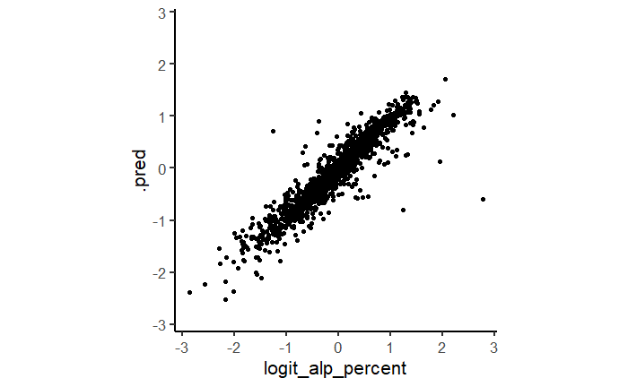

```r
  ggplot(polling_place_2pp_test) +
  aes(x = logit_alp_percent,
      y = .pred) +
  geom_point() +
  coord_obs_pred()
```

```r
member_preds <-
  polling_place_2pp_test %>%
  dplyr::select(logit_alp_percent) %>%
  bind_cols(predict(polling_place_2pp_stack, polling_place_2pp_test,
                    members = TRUE))
```

```
prediction from a rank-deficient fit may be misleading
```

```r
map_dfr(member_preds, rmse, truth = logit_alp_percent, data = member_preds) %>%
  mutate(member = colnames(member_preds))
```

| .metric | .estimator | .estimate | member |
| --- | --- | --- | --- |
| rmse | standard | 0.0000000 | logit_alp_percent |
| rmse | standard | 0.2540985 | .pred |
| rmse | standard | 0.2686833 | lm_resample_1_1 |
| rmse | standard | 0.2636304 | random_forest_resample_1_1 |
| rmse | standard | 0.2580984 | random_forest_resample_1_4 |
| rmse | standard | 0.3329198 | knn_resample_1_2 |
| rmse | standard | 0.3255683 | knn_resample_1_3 |
| rmse | standard | 0.9232835 | gbm_resample_1_37 |
| rmse | standard | 0.9232839 | gbm_resample_1_03 |
| rmse | standard | 0.3740908 | svm_resample_1_3 |

```r
map_dfr(member_preds, rsq, truth = logit_alp_percent, data = member_preds) %>%
  mutate(member = colnames(member_preds))
```

| .metric | .estimator | .estimate | member |
| --- | --- | --- | --- |
| rsq | standard | 1.00000000 | logit_alp_percent |
| rsq | standard | 0.87056099 | .pred |
| rsq | standard | 0.85518690 | lm_resample_1_1 |
| rsq | standard | 0.86334257 | random_forest_resample_1_1 |
| rsq | standard | 0.86670187 | random_forest_resample_1_4 |
| rsq | standard | 0.77868713 | knn_resample_1_2 |
| rsq | standard | 0.78768478 | knn_resample_1_3 |
| rsq | standard | 0.68050766 | gbm_resample_1_37 |
| rsq | standard | 0.06919822 | gbm_resample_1_03 |
| rsq | standard | 0.72295408 | svm_resample_1_3 |

Interestingly, an ensemble only gives us a 1.5% increase in R^2 over a linear model, with the best random forests outperforming linear regression by about 1%

## 6.4 Outlying booths